# Predicting Graduate Admission

# Section 1 - Introduction:

### Dataset for Graduate Admission

This dataset is created for prediction of Graduate Admissions from an Indian perspective.

The dataset contains several parameters which are considered important during the application for Masters Programs. The parameters included are : 1. GRE Scores i.e. Graduate Record Examination Scores ( out of 340 ) 2. TOEFL Scores i.e. Test of English as a Foreign Language ( out of 120 ) 3. University Rating ( out of 5 ) 4. SOP i.e. Statement of Purpose Strength ( out of 5 ) 5. LOR i.e. Letter of Recommendation Strength ( out of 5 ) 6. CGPA i.e. Cumulative Grade Point Average of Undergraduation (out of 10) 7. Research Experience ( either 0 or 1 ) 8. Chance of Admit ( ranging from 0 to 1 )

Inspiration This dataset was built with the purpose of helping students in shortlisting universities with their profiles. The predicted output gives them a fair idea about their chances for a particular university.

Acknowledgements This dataset is inspired by the UCLA Graduate Dataset. The test scores and GPA are in the older format. The dataset is owned by Mohan S Acharya.

Citation Please cite the following if you are interested in using the dataset : Mohan S Acharya, Asfia Armaan, Aneeta S Antony : A Comparison of Regression Models for Prediction of Graduate Admissions, IEEE International Conference on Computational Intelligence in Data Science 2019

> Source Link: https://www.kaggle.com/mohansacharya/graduate-admissions#Admission_Predict_Ver1.1.csv

# Section 2 - Data analysis plan:

> Finding the Correlation of all the variables through Correlation Matrix I got to know that CGPA and GRE_Score has the higest Correlation with Chance_of_Admit among all other variables so we can take this both for our Hypothesis.

> Hypothesis: The chance of admit increaces with the good grades that is with higher scores in CGPA (Cumulative Grade Point Average) and GRE Score (Graduate Record Examination Scores)

> Hypothesis Question: Finding the prediction of Chance of Admit of a student in Graduate Admission on the bases of CGPA (Cumulative Grade Point Average) and GRE Score (Graduate Record Examination Scores).

> Preforming the Univariate Analysis on CGPA and GRE_Score to check the outliners, IQR, Variance, Standard deviation, Shape of the distribution to understand the data.

> Preforming the Bivariate Analysis on (CGPA vs Chance_of_Admit) and (GRE_Score vs Chance_of_Admit) to find the Correlation between the variables which we have chosen for our analysis.

> Creating a Linear Modal to find the Equation of a Best Fit line to predict the Chance_of_Admit using CGPA and GRE_Score Variables, by the Linear Model we will find the Slope and Intercept of the Best Fit Line to create exact equation.

> Model diagnostics to assess whether the linear model we created is reliable or not by checking linearity, nearly normal residuals and constant variability, will also help to state a correctness of our hypothisis.

#### Loading Packages

```r
library(tidyverse)
library(here)
library(ggplot2)
library(gridExtra)
library(corrplot)
library(dplyr)
```

#### To call the Graduate Admission data we used here function that is loading data

```r
graduate_admission <- read_csv(here("Data", "Graduate_Admission.csv"))
```

#### Glimpse Dataset

```r
glimpse(graduate_admission)
```

```
## Observations: 500
## Variables: 9
## $ Serial_No         <dbl> 1, 2, 3, 4, 5, 6, 7, 8, 9, 10, 11, 12, 13, 14, 15, …
## $ GRE_Score         <dbl> 337, 324, 316, 322, 314, 330, 321, 308, 302, 323, 3…
## $ TOEFL_Score       <dbl> 118, 107, 104, 110, 103, 115, 109, 101, 102, 108, 1…
## $ University_Rating <dbl> 4, 4, 3, 3, 2, 5, 3, 2, 1, 3, 3, 4, 4, 3, 3, 3, 3, …
## $ SOP               <dbl> 4.5, 4.0, 3.0, 3.5, 2.0, 4.5, 3.0, 3.0, 2.0, 3.5, 3…
## $ LOR               <dbl> 4.5, 4.5, 3.5, 2.5, 3.0, 3.0, 4.0, 4.0, 1.5, 3.0, 4…
## $ CGPA              <dbl> 9.65, 8.87, 8.00, 8.67, 8.21, 9.34, 8.20, 7.90, 8.0…
## $ Research          <dbl> 1, 1, 1, 1, 0, 1, 1, 0, 0, 0, 1, 1, 1, 1, 1, 0, 0, …
## $ Chance_of_Admit   <dbl> 0.92, 0.76, 0.72, 0.80, 0.65, 0.90, 0.75, 0.68, 0.5…
```

#### Checking NA values in our dataset

```r
table(is.na(graduate_admission)) # No NA values
```

```
##
## FALSE
##  4500
```

– Hence this are No NA values in our Dataset

#### Finding correlation of all the variables through correlation matrix and round off value to the 2nd place.

```r
cor_graduate_admission <- cor(graduate_admission)
cor_graduate_admission <- round(cor_graduate_admission, 2)
cor_graduate_admission
```

```
##                   Serial_No GRE_Score TOEFL_Score University_Rating   SOP  LOR
## Serial_No              1.00     -0.10       -0.14             -0.07 -0.14 0.00
## GRE_Score             -0.10      1.00        0.83              0.64  0.61 0.52
## TOEFL_Score           -0.14      0.83        1.00              0.65  0.64 0.54
## University_Rating     -0.07      0.64        0.65              1.00  0.73 0.61
## SOP                   -0.14      0.61        0.64              0.73  1.00 0.66
## LOR                    0.00      0.52        0.54              0.61  0.66 1.00
## CGPA                  -0.07      0.83        0.81              0.71  0.71 0.64
## Research              -0.01      0.56        0.47              0.43  0.41 0.37
## Chance_of_Admit        0.01      0.81        0.79              0.69  0.68 0.65
##                    CGPA Research Chance_of_Admit
## Serial_No         -0.07    -0.01            0.01
## GRE_Score          0.83     0.56            0.81
## TOEFL_Score        0.81     0.47            0.79
## University_Rating  0.71     0.43            0.69
## SOP                0.71     0.41            0.68
## LOR                0.64     0.37            0.65
## CGPA               1.00     0.50            0.88
## Research           0.50     1.00            0.55
## Chance_of_Admit    0.88     0.55            1.00
```

> Finding the Correlation of all the variables through Correlation Matrix I got to know that CGPA and GRE_Score has the higest Correlation with Chance_of_Admit among all other variables so we can take this both for our Hypothesis.

> Hypothesis Question: Finding the prediction of Chance of Admit of a student in Graduate Admission on the bases of CGPA (Cumulative Grade Point Average) and GRE Score (Graduate Record Examination Scores).

> So by taking Hypothesis that chance of admit increaces with the good grades that is with higher scores in CGPA (Cumulative Grade Point Average) and GRE Score (Graduate Record Examination Scores)

#### Converting Research, SOP, LOR, University Rating variables as factor as they are categorical variable and removing Serial_No variable as it is of no use.

```r
graduate_admission.fac <- graduate_admission %>% mutate(Research = as.factor(Research), SOP = as.factor(SOP), LOR = as.factor(LOR), University_Rating = as.factor(University_Rating))

graduate_admission.fac <- graduate_admission.fac %>% select(-Serial_No)
```

```r
head(graduate_admission.fac)
```

| GRE_Score | TOEFL_Score | University_Rating | SOP | LOR | CGPA | Research | Chance_of_Admit |
| --- | --- | --- | --- | --- | --- | --- | --- |
| 337 | 118 | 4 | 4.5 | 4.5 | 9.65 | 1 | 0.92 |
| 324 | 107 | 4 | 4 | 4.5 | 8.87 | 1 | 0.76 |
| 316 | 104 | 3 | 3 | 3.5 | 8.00 | 1 | 0.72 |
| 322 | 110 | 3 | 3.5 | 2.5 | 8.67 | 1 | 0.80 |
| 314 | 103 | 2 | 2 | 3 | 8.21 | 0 | 0.65 |
| 330 | 115 | 5 | 4.5 | 3 | 9.34 | 1 | 0.90 |

##### Summary of dataset

```r
summary(graduate_admission.fac)
```

```
##    GRE_Score      TOEFL_Score    University_Rating      SOP          LOR
##  Min.   :290.0   Min.   : 92.0   1: 34             4      :89   3      :99
##  1st Qu.:308.0   1st Qu.:103.0   2:126             3.5    :88   4      :94
##  Median :317.0   Median :107.0   3:162             3      :80   3.5    :86
##  Mean   :316.5   Mean   :107.2   4:105             2.5    :64   4.5    :63
##  3rd Qu.:325.0   3rd Qu.:112.0   5: 73             4.5    :63   2.5    :50
##  Max.   :340.0   Max.   :120.0                     2      :43   5      :50
##                                                    (Other):73   (Other):58
##       CGPA       Research Chance_of_Admit
##  Min.   :6.800   0:220    Min.   :0.3400
##  1st Qu.:8.127   1:280    1st Qu.:0.6300
##  Median :8.560            Median :0.7200
##  Mean   :8.576            Mean   :0.7217
##  3rd Qu.:9.040            3rd Qu.:0.8200
##  Max.   :9.920            Max.   :0.9700
##
```

## Performing Univariate Analysis for CGPA variable

#### Summary of CGPA variable

```r
summary(graduate_admission.fac$CGPA)
```

```
##    Min. 1st Qu.  Median    Mean 3rd Qu.    Max.
##   6.800   8.127   8.560   8.576   9.040   9.920
```

##### Plotting a Histogram of CGPA

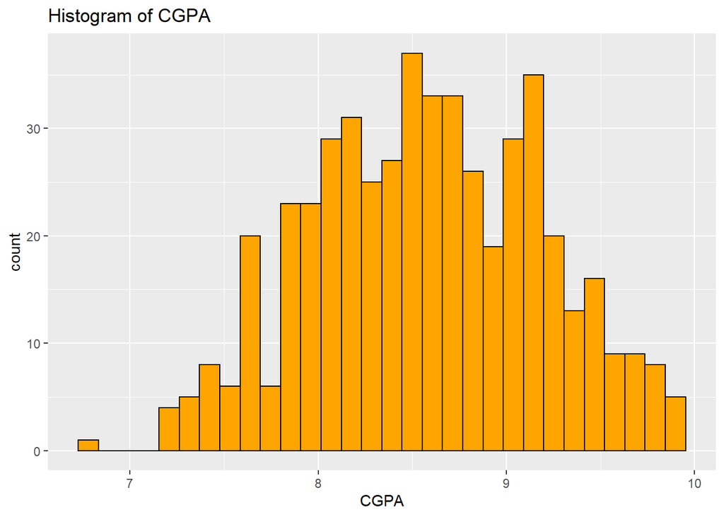

```r
ggplot(graduate_admission.fac, aes(x = CGPA)) +
  geom_histogram(fill = 'orange', colour = 'black') +
  ggtitle("Histogram of CGPA")
```

#### Calculating Binwitdth of CGPA

```r
bin_width_CGPA = (max(graduate_admission.fac$CGPA) - min(graduate_admission.fac$CGPA)) / 30
bin_width_CGPA
```

```
## [1] 0.104
```

##### Plotting Histogram with correct binwidth

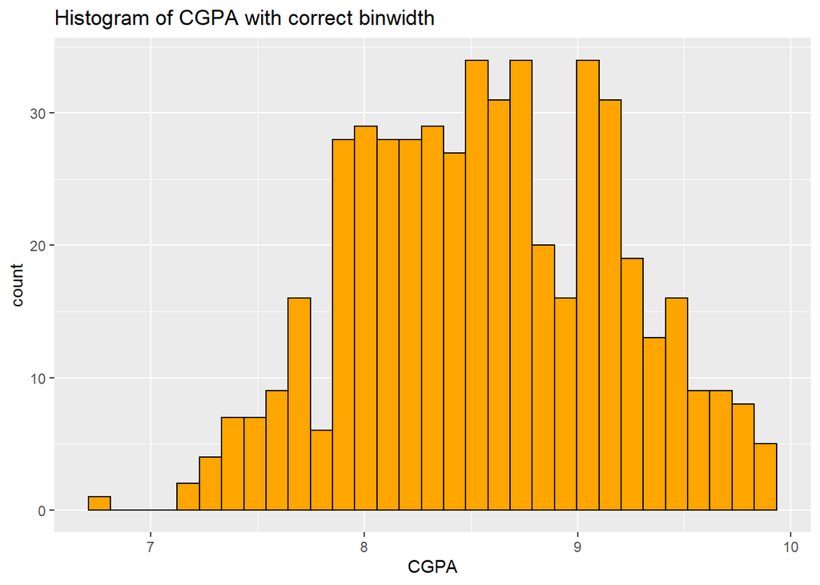

```r
ggplot(graduate_admission.fac, aes(x = CGPA))  +
  geom_histogram(fill = 'orange', colour = 'black', binwidth = 0.104) +
  ggtitle("Histogram of CGPA with correct binwidth")
```

> From the above histogram we can see that there is a suspected outlier in our data for CGPA variable so to check it is really a outlier or not?

```r
graduate_admission.fac %>% filter(CGPA < 7.5) %>% arrange(CGPA)
```

| GRE_Score | TOEFL_Score | University_Rating | SOP | LOR | CGPA | Research | Chance_of_Admit |
| --- | --- | --- | --- | --- | --- | --- | --- |
| 300 | 99 | 1 | 3 | 2 | 6.80 | 1 | 0.36 |
| 295 | 93 | 1 | 2 | 2 | 7.20 | 0 | 0.46 |
| 298 | 97 | 2 | 2 | 3 | 7.21 | 0 | 0.45 |
| 310 | 110 | 1 | 1.5 | 4 | 7.23 | 1 | 0.58 |
| 302 | 99 | 1 | 2 | 2 | 7.25 | 0 | 0.57 |
| 296 | 99 | 2 | 3 | 3.5 | 7.28 | 0 | 0.47 |
| 310 | 99 | 2 | 1.5 | 2 | 7.30 | 0 | 0.54 |
| 295 | 96 | 2 | 1.5 | 2 | 7.34 | 0 | 0.47 |
| 299 | 94 | 1 | 1 | 1 | 7.34 | 0 | 0.42 |
| 294 | 93 | 1 | 1.5 | 2 | 7.36 | 0 | 0.46 |

[output cut: 8 more lines]

– So there is just one student with less then 7 CGPA but we consider as suspected outliner but we cannot consider him as outlier as there are other variables which are also affecting the Chance of Admit of a student.

– Hence no transformation is required as no outliner is present in dataset

### To find the shape and skewness of the distribution in CGPA

##### Plotting histogram of CGPA with Average CGPA value i.e Mean of CGPA

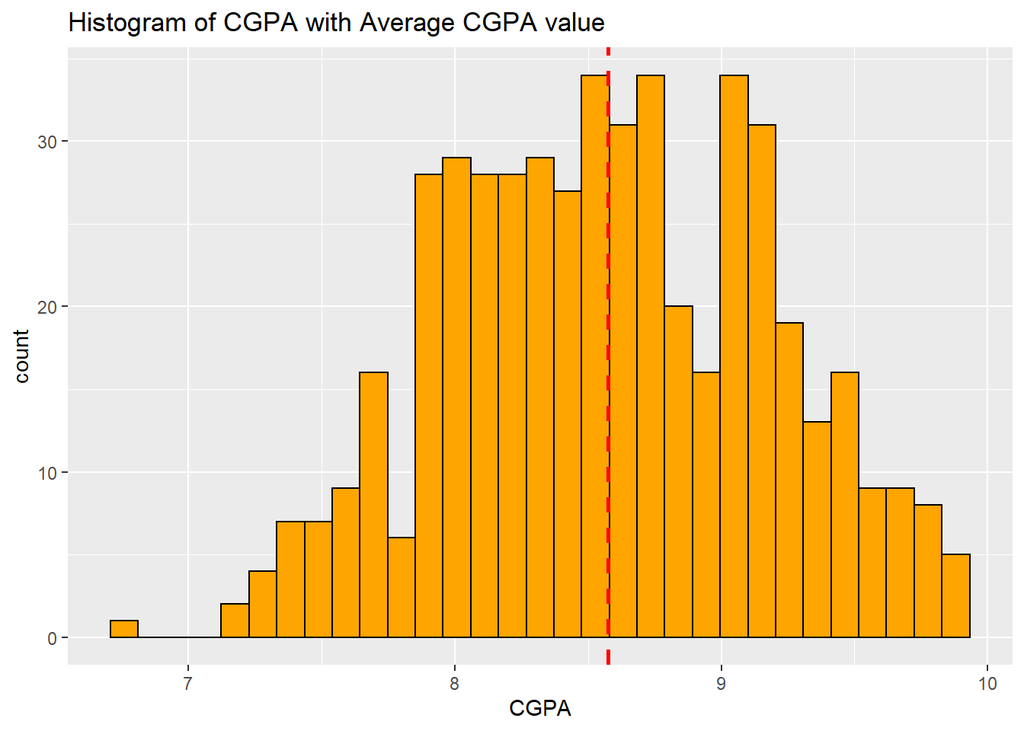

```r
ggplot(graduate_admission.fac, aes(x = CGPA))  +
  geom_histogram(fill = 'orange', colour = 'black', binwidth = 0.104) +
  geom_vline(xintercept = mean(graduate_admission.fac$CGPA), linetype = "dashed", colour = 'red', size = 1) +

  ggtitle("Histogram of CGPA with Average CGPA value")
```

#### Plotting histogram of CGPA with Median of CGPA

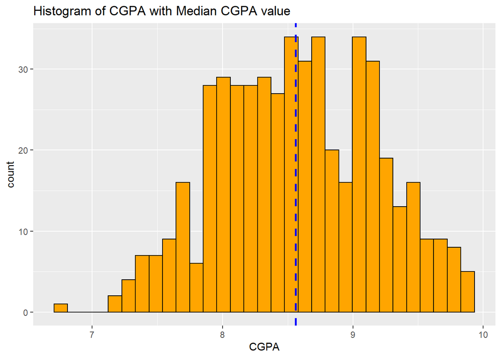

```r
ggplot(graduate_admission.fac, aes(x = CGPA))  +
  geom_histogram(fill = 'orange', colour = 'black', binwidth = 0.104) +
  geom_vline(xintercept = median(graduate_admission.fac$CGPA), linetype = "dashed", colour = 'blue', size = 1) +
  ggtitle("Histogram of CGPA with Median CGPA value")
```

#### Plotting Histogram with Comparing Average CGPA with Median CGPA value

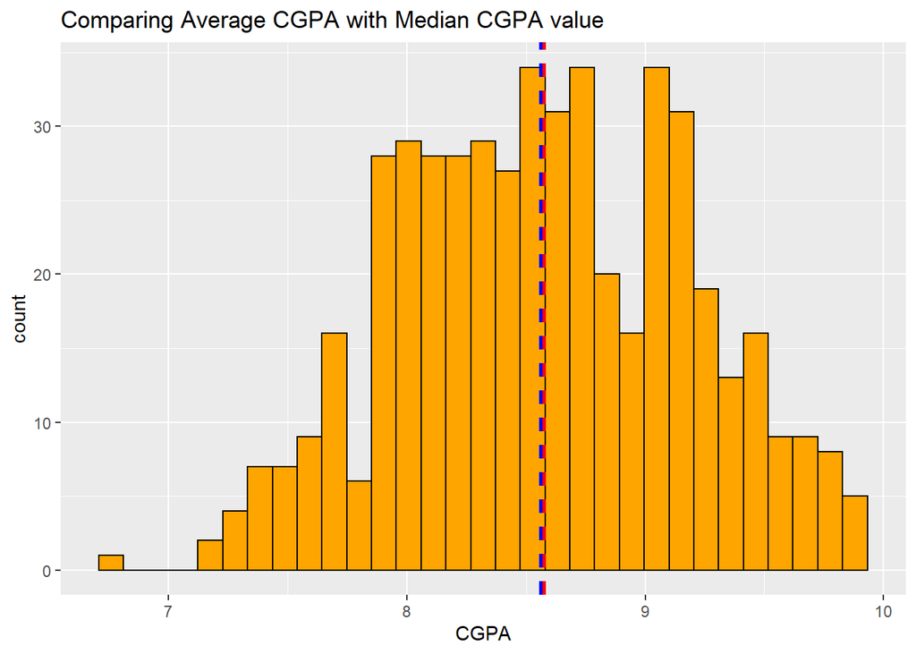

```r
ggplot(graduate_admission.fac, aes(x = CGPA))  +
  geom_histogram(fill = 'orange', colour = 'black', binwidth = 0.104) +
  geom_vline(xintercept = mean(graduate_admission.fac$CGPA), linetype = "dashed", colour = 'red', size = 1) + geom_vline(xintercept = median(graduate_admission.fac$CGPA), linetype = "dashed", colour = 'blue', size = 1) +
  ggtitle("Comparing Average CGPA with Median CGPA value")
```

> Shape and Skewness of the distribution

—- The above plot is showing that Mean value(that is average CGPA) is greater than the Median Value that we expect for the Right skewed distribution and shape is Multimodal.

> Central Tendency

—- The mean is greater than the median, which confirms the skewness noted in the histogram.

—- It would be better to use the median as a measure of central tendency given that the distribution is skewed. We know that the median is more robust to outliers than the mean so this should give us a better sense of the centre of the data distribution.

> Measure of Spread

– Finding IQR

```r
IQR(graduate_admission.fac$CGPA)
```

```
## [1] 0.9125
```

– Finding Standerd Deviation

```r
sd(graduate_admission.fac$CGPA)
```

```
## [1] 0.6048128
```

We should use the interquartile range as a measure of spread since it is a more robust measure than standard deviation in the presence of skewness/ outliers.

### Performing Bivariate Analysis on CGPA vs Chance_of_Admit variable

##### Visualising CGPA with Chance_of_Admit

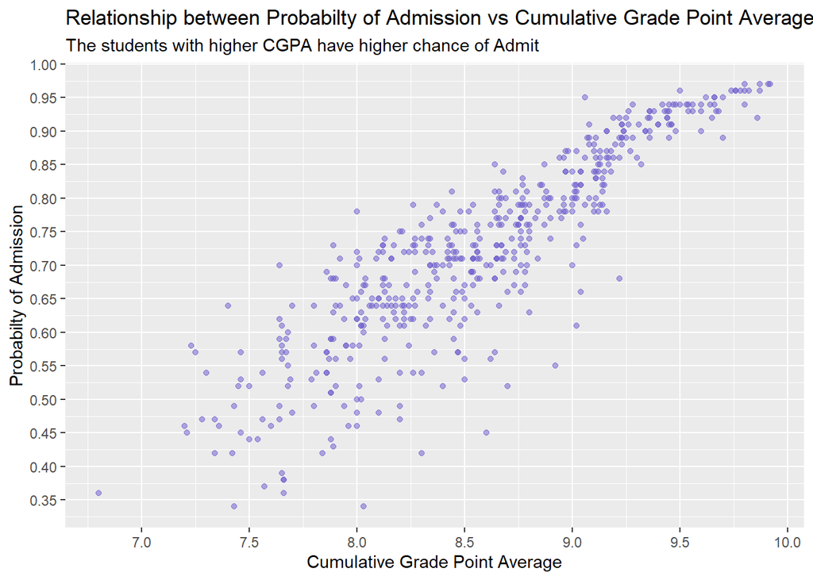

```r
ggplot(graduate_admission.fac, aes(CGPA, Chance_of_Admit)) +
  geom_point(alpha = 0.5, col='slateblue') +
  scale_y_continuous(breaks = seq(0,1, by = 0.05)) +
  scale_x_continuous(breaks = seq(5,10, by = 0.5)) +
  xlab("Cumulative Grade Point Average") +
  ylab("Probabilty of Admission") +
  ggtitle("Relationship between Probabilty of Admission vs Cumulative Grade Point Average",
          subtitle = "The students with higher CGPA have higher chance of Admit")
```

##### Plotting Scatter Plot of CGPA vs Chance_of_Admit with a trend line that is the best fit line for the given relationship

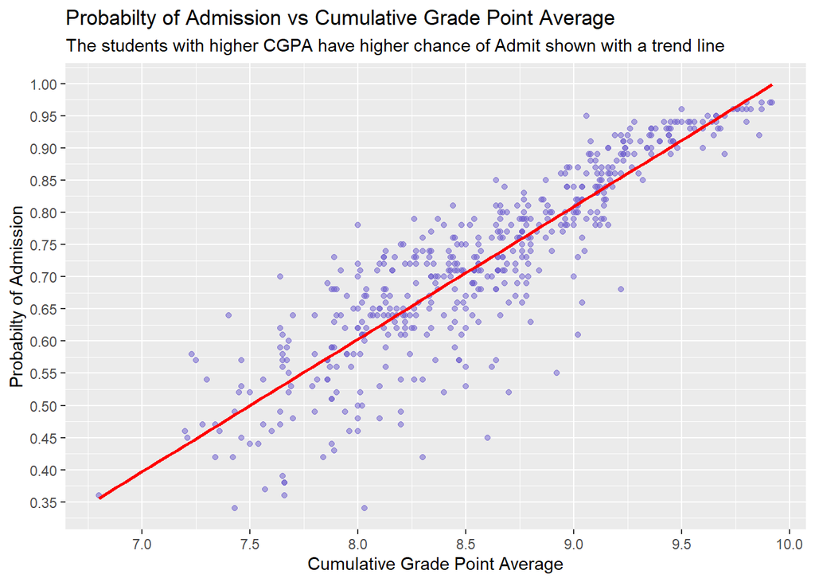

```r
ggplot(graduate_admission.fac, aes(CGPA, Chance_of_Admit)) +
  geom_point(alpha = 0.5, col='slateblue') +
  geom_smooth(se = FALSE, color = "red", method = "lm") +
  scale_y_continuous(breaks = seq(0,1, by = 0.05)) +
  scale_x_continuous(breaks = seq(5,10, by = 0.5)) +
  xlab("Cumulative Grade Point Average") +
  ylab("Probabilty of Admission") +
  ggtitle("Probabilty of Admission vs Cumulative Grade Point Average",
          subtitle = "The students with higher CGPA have higher chance of Admit shown with a trend line")
```

> The form, direction, and strength of the observed relationship that is CGPA vs Chance_of_Admit.

—- It appears that Chance_of_Admit has a Positive, linear relation with the CGPA (or at least could potentially be modeled as such) and appears to be somewhat of a fairly strong relationship. As it is said that with higher scores there is a higher chance of getting a admit from good University.

—- The value of the correlation coefficient is on the stronger side, confirming what we see in the plot.

```r
cor(graduate_admission.fac$Chance_of_Admit, graduate_admission.fac$CGPA)
```

```
## [1] 0.8824126
```

– We have already checked the correlation coefficient of all the variables, in the starting of our project and then selected the one which has the higest correlation coefficient which we have proved here again by performing Bivariate Analysis.

– Till now our Hypothesis is going right with the above facts.

### Preforming Linear model

##### Using a scatter plot to display the relationship between Chance_of_Admit and CGPA.

– Since CGPA is the predictor variable, that is, the explanatory variable, then the scatter plot should have CGPA on the x axis and Chance_of_Admit (the response variable) on the y axis.

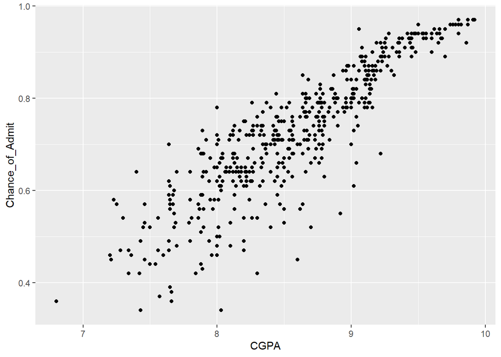

```r
ggplot(graduate_admission.fac, aes(CGPA, Chance_of_Admit)) +
  geom_point()
```

–The relationship looks linear.

–I would feel comfortable using a linear model to predict the number of Chance_of_Admit. It’s not a perfect relationship but it seems like it would do a pretty good job predicting Chance_of_Admit from CGPA.

– If the relationship looks linear, we can quantify the strength of the relationship with the correlation coefficient.

```r
cor(graduate_admission.fac$Chance_of_Admit, graduate_admission.fac$CGPA)
```

```
## [1] 0.8824126
```

– While there is some variation in the data, there are no unusual observations.

##### Creating Linear Model for Chance_of_Admit ~ CGPA

```r
m1 <- lm(Chance_of_Admit ~ CGPA, data = graduate_admission.fac)
m1
```

```
##
## Call:
## lm(formula = Chance_of_Admit ~ CGPA, data = graduate_admission.fac)
##
## Coefficients:
## (Intercept)         CGPA
##     -1.0443       0.2059
```

##### Summary of Linear Model m1

```r
summary(m1)
```

```
##
## Call:
## lm(formula = Chance_of_Admit ~ CGPA, data = graduate_admission.fac)
##
## Residuals:
##       Min        1Q    Median        3Q       Max
## -0.276592 -0.028169  0.006619  0.038483  0.176961
##
## Coefficients:
##             Estimate Std. Error t value Pr(>|t|)
## (Intercept) -1.04434    0.04230  -24.69   <2e-16 ***
## CGPA         0.20592    0.00492   41.85   <2e-16 ***
## ---
## Signif. codes:  0 '***' 0.001 '**' 0.01 '*' 0.05 '.' 0.1 ' ' 1
##
## Residual standard error: 0.06647 on 498 degrees of freedom
## Multiple R-squared:  0.7787, Adjusted R-squared:  0.7782
## F-statistic:  1752 on 1 and 498 DF,  p-value: < 2.2e-16
```

> The slope for the linear model (from least squares algotithm using the lm() function) is 0.20592.

> the intercept for the linear model is -1.04434.

> The equation for least squares regression line for Chance_of_Admit vs CGPA for the linear model:

$$\hat{y} = -1.04434 + 0.20592 * CGPA$$

> Slope of 0.20592 tells us that for every “CGPA”, on average, a student will have 0.20592 more “Chance_of_Admit”. This would imply that a student with more CGPA is more likely to be successful scince the student would be more likly to have a Chance of Admit in a good university

##### Prediction and prediction errors

> If a student saw the least squares regression line and not the actual data, how student will predict the Chance of Admit for a CGPA of 8? Is this an overestimate or an underestimate, and by how much? In other words, what is the residual for this prediction?

– The student will predict -1.04434 + 0.20592*CGPA Chance_of_Admit

– To calculate a residual we use the formula: ei=yi−y^i, where
$$y_i$$
is the actual value from the data and y^i is the corresponding value predicted by our linear model.

> Predicted value for Chance of Admit where CGPA = 8

```r
pred_COA_CGPA <- -1.04434 + 0.20592*8
pred_COA_CGPA
```

```
## [1] 0.60302
```

> To Calculate the actual Chance of Admit we will filter students with CGPA = 8

```r
CGPA_8 <- graduate_admission.fac %>% filter(CGPA == 8)
CGPA_8
```

| GRE_Score | TOEFL_Score | University_Rating | SOP | LOR | CGPA | Research | Chance_of_Admit |
| --- | --- | --- | --- | --- | --- | --- | --- |
| 316 | 104 | 3 | 3 | 3.5 | 8 | 1 | 0.72 |
| 302 | 102 | 1 | 2 | 1.5 | 8 | 0 | 0.50 |
| 307 | 109 | 3 | 4 | 3 | 8 | 1 | 0.62 |
| 319 | 106 | 3 | 4 | 3 | 8 | 1 | 0.65 |
| 308 | 110 | 3 | 3.5 | 3 | 8 | 1 | 0.46 |
| 334 | 116 | 4 | 4 | 3 | 8 | 1 | 0.78 |
| 322 | 110 | 3 | 3 | 3.5 | 8 | 0 | 0.70 |
| 306 | 100 | 2 | 3 | 3 | 8 | 0 | 0.48 |
| 309 | 106 | 2 | 2.5 | 2.5 | 8 | 0 | 0.62 |

> As there are many different Chance of Admit of students with CGPA = 8 as other factors are changing the Chance of Admit of a student so we will not consider that for now and will just take average of all of them and then will compare

```r
actual_COA_CGPA <-mean(CGPA_8$Chance_of_Admit)
actual_COA_CGPA
```

```
## [1] 0.6144444
```

```r
ei_CGPA = actual_COA_CGPA - pred_COA_CGPA
ei_CGPA
```

```
## [1] 0.01142444
```

> Since the residual for this point is positive, that means the value predicted by our model is an underestimate

### Model diagnostics

> Since the equation for our model is predicted: Chance_of_Admit^ = -1.04434 + 0.20592*CGPA, we can use this in a mutate statement to calculated our predicted values

> Once we have our predicted values we can calculate the residuals as residuals = actual values − predicted values

```r
ga_test_CGPA <- graduate_admission.fac %>% mutate(pred_Chance_of_Admit_CGPA = -1.04434 + 0.20592 * CGPA,
                                             residuals_CGPA = Chance_of_Admit - pred_Chance_of_Admit_CGPA)

ga_test_CGPA <- ga_test_CGPA %>% select(Chance_of_Admit, pred_Chance_of_Admit_CGPA, CGPA, residuals_CGPA)
ga_test_CGPA
```

| Chance_of_Admit | pred_Chance_of_Admit_CGPA | CGPA | residuals_CGPA |
| --- | --- | --- | --- |
| 0.92 | 0.9427880 | 9.65 | -0.0227880 |
| 0.76 | 0.7821704 | 8.87 | -0.0221704 |
| 0.72 | 0.6030200 | 8.00 | 0.1169800 |
| 0.80 | 0.7409864 | 8.67 | 0.0590136 |
| 0.65 | 0.6462632 | 8.21 | 0.0037368 |
| 0.90 | 0.8789528 | 9.34 | 0.0210472 |
| 0.75 | 0.6442040 | 8.20 | 0.1057960 |
| 0.68 | 0.5824280 | 7.90 | 0.0975720 |
| 0.50 | 0.6030200 | 8.00 | -0.1030200 |
| 0.45 | 0.7265720 | 8.60 | -0.2765720 |

[output cut: 490 more lines]

##### Plotting CGPA vs residuals_CGPA

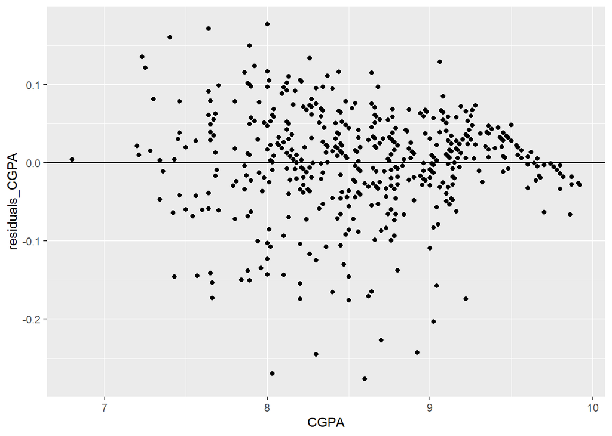

```r
ggplot(ga_test_CGPA, aes(x = CGPA, y = residuals_CGPA)) +
  geom_point() +
  geom_hline(yintercept = 0)
```

> There is no apparent pattern in the residual plot above. This means that a linear model is appropriate to describe the relationship between Chance_of_Admit and CGPA, that is, the condition of “linearity” has been met.

> Nearly normal residuals: To check this condition, we can look at a histogram.

##### Plotting histogram of residuals_CGPA

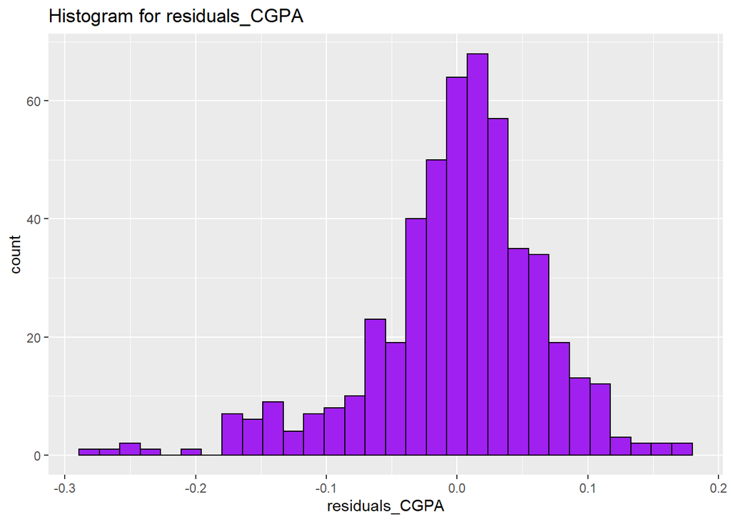

```r
ggplot(ga_test_CGPA, aes(x = residuals_CGPA)) +
   geom_histogram(fill = 'purple', colour = 'black') +
   ggtitle("Histogram for residuals_CGPA")
```

##### Finding correct binwidth

```r
xx <- (max(ga_test_CGPA$residuals_CGPA) - min(ga_test_CGPA$residuals_CGPA))/30
xx
```

```
## [1] 0.0151184
```

##### Plotting Histogram for residuals_CGPA with correct binwidth

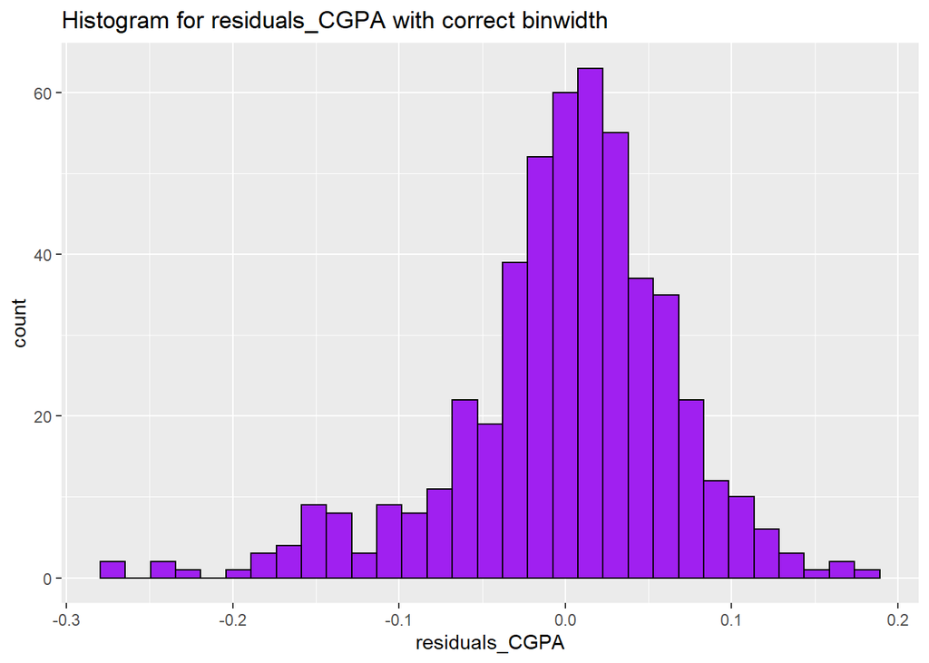

```r
ggplot(ga_test_CGPA, aes(x = residuals_CGPA)) +
   geom_histogram(fill = 'purple', colour = 'black', binwidth = 0.0151184) +
  ggtitle("Histogram for residuals_CGPA with correct binwidth")
```

> Based on the histogram above, the residuals appear to be nearly normal so this condition is met.

##### To check Constant variability: I will redraw the plot in The Scatter plot of Residuals vs CGPA with some extra horizontal lines:

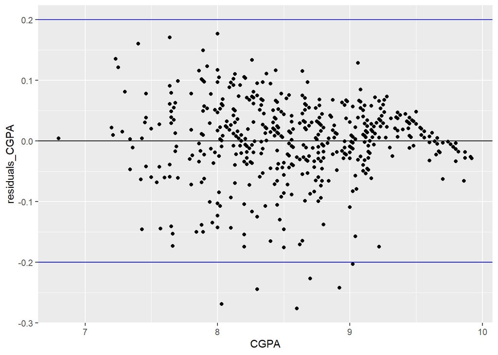

```r
ggplot(ga_test_CGPA, aes(x = CGPA, y = residuals_CGPA)) +
  geom_point() +
  geom_hline(yintercept = 0) +
  geom_hline(yintercept = 0.2, color = 'blue') +
  geom_hline(yintercept = -0.2, color = 'blue')
```

–So by our Hypothisis that with greater CGPA there is greater Chance of Admit in the Good University is correct by the equataion on best fit line Chance_of_Admit = -1.04434 + 0.20592 * CGPA. Hence if a student has higher CGPA his/ her chance of getting admit into a good university increases.

## Performing Univariate Analysis for GRE_Score variable

#### Summary of GRE_Score variable

```r
summary(graduate_admission.fac$GRE_Score)
```

```
##    Min. 1st Qu.  Median    Mean 3rd Qu.    Max.
##   290.0   308.0   317.0   316.5   325.0   340.0
```

##### Plotting a Histogram of GRE_Score

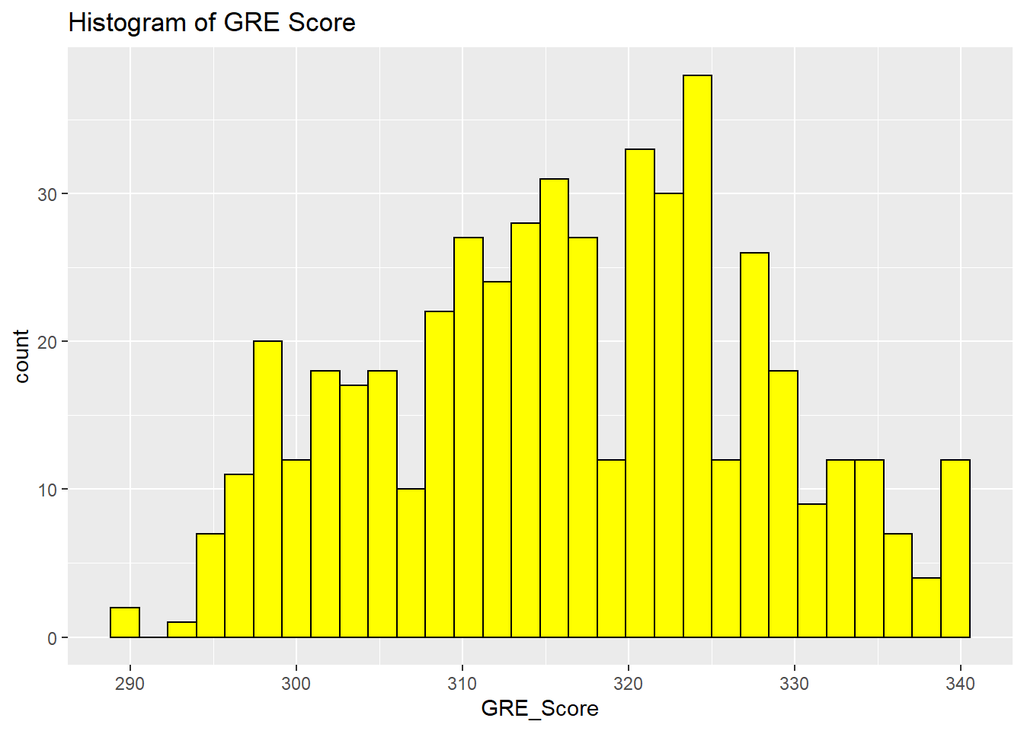

```r
ggplot(graduate_admission.fac, aes(x = GRE_Score)) +
  geom_histogram(fill = 'yellow', colour = 'black') +
  ggtitle("Histogram of GRE Score")
```

##### Calculating Binwitdth of GRE_Score

```r
bin_width_GRE_Score = (max(graduate_admission.fac$GRE_Score) - min(graduate_admission.fac$GRE_Score)) / 30
bin_width_GRE_Score
```

```
## [1] 1.666667
```

##### Plotting Histogram with correct binwidth

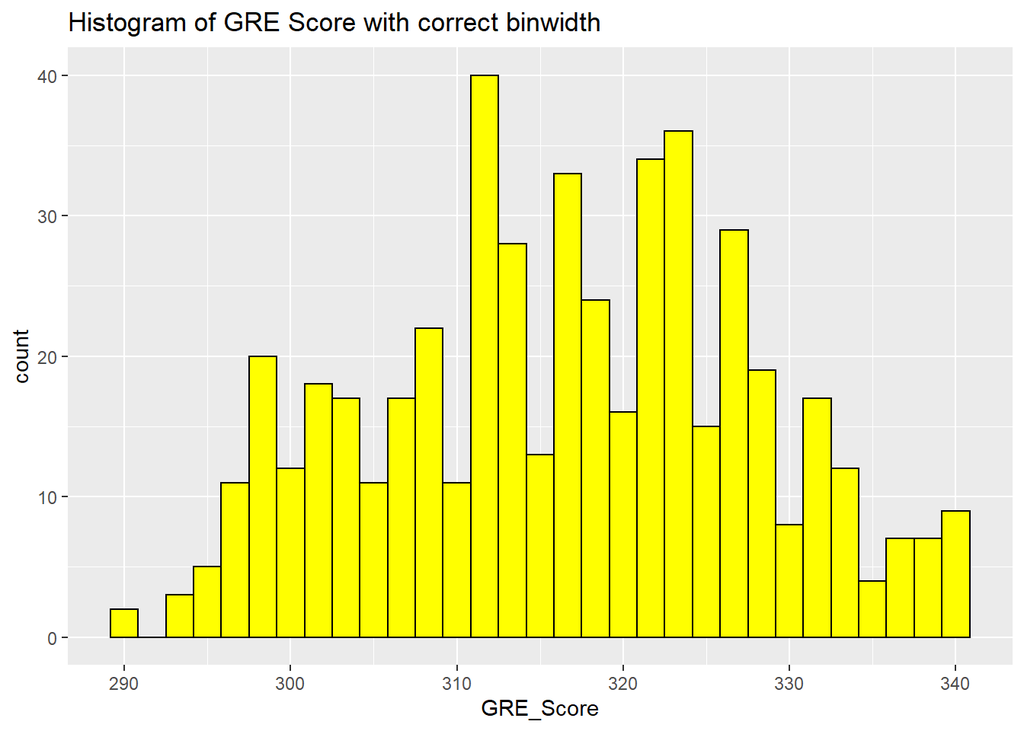

```r
ggplot(graduate_admission.fac, aes(x = GRE_Score))  +
  geom_histogram(fill = 'yellow', colour = 'black', binwidth = 1.666667) +
  ggtitle("Histogram of GRE Score with correct binwidth")
```

> From the above histogram we can see that there is a suspected outlier in our data for GRE_Score variable so to check it is really a outlier or not?

```r
graduate_admission.fac %>% filter(GRE_Score < 295) %>% arrange(GRE_Score)
```

| GRE_Score | TOEFL_Score | University_Rating | SOP | LOR | CGPA | Research | Chance_of_Admit |
| --- | --- | --- | --- | --- | --- | --- | --- |
| 290 | 104 | 4 | 2 | 2.5 | 7.46 | 0 | 0.45 |
| 290 | 100 | 1 | 1.5 | 2 | 7.56 | 0 | 0.47 |
| 293 | 97 | 2 | 2 | 4 | 7.80 | 1 | 0.64 |
| 294 | 93 | 1 | 1.5 | 2 | 7.36 | 0 | 0.46 |
| 294 | 95 | 1 | 1.5 | 1.5 | 7.64 | 0 | 0.49 |

– The students with score less then 293 are suspected as outliner. – But if we see that all though they have less GRE_Score but we know that there are other variables which are going to affect the Chance of Admit of a Student so we cannot take these students with 290 GRE Score as outliners.

– Hence no transformation is required as no outliner is present in dataset.